# Tugas Pertemuan 3 Metode Peramalan Deret Waktu

Muhammad Rizky Fajar

## Dataset

Dataset dapat diakses secara keseluruhan pada laman https://www.kaggle.com/datasets/theforcecoder/wind-power-forecasting. Dateset tersebut merupakan data dari suatu kincir angin tertentu yang mengandung berbagai fitur cuaca, turbin dan rotor. Data telah direkam sejak Januari 2018 hingga Maret 2020 dengan interval waktu 10 menit.

Penelitian ini menggunakan 100 baris data, mulai dari baris data pada 2020-03-22 08:50:00+00:00 hingga 2020-03-23 01:20:00+00:00. Peubah yang digunakan merupakan peubah “ActivePower” yang berfungsi sebagai peubah tak bebas ($Y_t$) serta peubah “WindSpeed” sebagai peubah bebas ($X_t$).

## Impor Data

```r
library(rio)
df <- import("https://raw.githubusercontent.com/mhdrfajar/mpdw/main/Pertemuan%203/data_turbin%20-%20Copy.csv")
colnames(df)[colnames(df)=="ActivePower"] = "yt"
colnames(df)[colnames(df)=="WindSpeed"] = "xt"
summary(df)
```

```
##        t                yt               Y(t-1)               xt
##  Min.   :  1.00   Min.   :  -9.158   Min.   :  -9.158   Min.   :2.367
##  1st Qu.: 25.75   1st Qu.: 240.919   1st Qu.: 237.776   1st Qu.:4.720
##  Median : 50.50   Median : 513.800   Median : 513.114   Median :5.814
##  Mean   : 50.50   Mean   : 499.085   Mean   : 498.930   Mean   :5.597
##  3rd Qu.: 75.25   3rd Qu.: 714.182   3rd Qu.: 718.279   3rd Qu.:6.564
##  Max.   :100.00   Max.   :1493.368   Max.   :1493.368   Max.   :8.161
##                                      NA's   :1
```

```r
dim(df)
```

```
## [1] 100   4
```

```r
df
```

```
##       t          yt      Y(t-1)       xt
## 1     1   -9.157692          NA 3.039088
## 2     2   -2.290742   -9.157692 2.646405
## 3     3   -8.453905   -2.290742 2.366922
## 4     4   38.542468   -8.453905 3.506605
## 5     5   66.727847   38.542468 3.158759
## 6     6   35.653790   66.727847 3.382439
## 7     7    4.248057   35.653790 3.446361
## 8     8  384.090092    4.248057 5.339905
## 9     9  257.258803  384.090092 4.691105
## 10   10  297.503005  257.258803 4.690155
## 11   11  105.444947  297.503005 3.688116
## 12   12  140.189727  105.444947 3.936070
## 13   13  160.096012  140.189727 3.957842
## 14   14    8.684160  160.096012 3.264255
```

[output cut: 86 more lines]

## Pembagian Data

Pembagian data latih dan data uji dilakukan dengan perbandingan 80% data latih dan 20% data uji.

```r
#SPLIT DATA
train<-df[1:80,]
test<-df[81:100,]
```

Mengubah format data menjadi time series

```r
#data time series
train.ts<-ts(train)
test.ts<-ts(test)
df.ts<-ts(df)
```

## Model Koyck

Model Koyck didasarkan pada asumsi bahwa semakin jauh jarak lag peubah independen dari periode sekarang maka semakin kecil pengaruh peubah lag terhadap peubah dependen.

Koyck mengusulkan suatu metode untuk menduga model dinamis distributed lag dengan mengasumsikan bahwa semua koefisien $\beta$ mempunyai tanda sama.

Model kyock merupakan jenis paling umum dari model infinite distributed lag dan juga dikenal sebagai geometric lag

$$y_t=a(1-\lambda)+\beta_0X_t+\beta_1Z_t+\lambda Y_{t-1}+V_t$$

dengan
$$V_t=u_t-\lambda
u_{t-1}$$

### Pemodelan

Pemodelan model Koyck dengan `R` dapat menggunakan `dLagM::koyckDlm()` . Fungsi umum dari `koyckDlm` adalah sebagai berikut.

```r
koyckDlm(x , y , intercept)
```

Fungsi `koyckDlm()` akan menerapkan model lag terdistribusi dengan transformasi Koyck satu prediktor. Nilai `x` dan `y` tidak perlu sebagai objek *time series* (`ts`). `intercept` dapat dibuat `TRUE` untuk memasukkan intersep ke dalam model.

```r
#MODEL KOYCK
model.koyck <- koyckDlm(x = train$xt, y = train$yt)
summary(model.koyck)
```

```
##
## Call:
## "Y ~ (Intercept) + Y.1 + X.t"
##
## Residuals:
##     Min      1Q  Median      3Q     Max
## -213.32  -61.11   -5.51   32.23  506.56
##
## Coefficients:
##              Estimate Std. Error t value Pr(>|t|)
## (Intercept) -139.8033   172.7125  -0.809 0.420780
## Y.1            0.7076     0.1737   4.074 0.000113 ***
## X.t           53.0105    45.8472   1.156 0.251204
## ---
## Signif. codes:  0 '***' 0.001 '**' 0.01 '*' 0.05 '.' 0.1 ' ' 1
##
## Residual standard error: 112.3 on 76 degrees of freedom
## Multiple R-Squared: 0.8946,  Adjusted R-squared: 0.8919
## Wald test: 304.9 on 2 and 76 DF,  p-value: < 2.2e-16
##
## Diagnostic tests:
## NULL
##
##                              alpha     beta       phi
## Geometric coefficients:  -478.0738 53.01046 0.7075697
```

```r
AIC(model.koyck)
```

```
## [1] 975.1134
```

```r
BIC(model.koyck)
```

```
## [1] 984.5912
```

$$\hat{Y_t}= -139.8033+53.0105X_t+0.7076Y_{t-1}$$

### Peramalan dan Akurasi

Berikut adalah hasil peramalan y untuk 20 periode kedepan menggunakan model koyck

```r
fore.koyck <- forecast(model = model.koyck, x=test$xt, h=20)
fore.koyck
```

```
## $forecasts
##  [1] 513.6602 480.9510 428.6252 409.9677 416.0138 427.6418 434.2914 458.6682
##  [9] 415.5135 410.5407 440.9059 451.8123 502.0029 499.8817 558.1789 581.3018
## [17] 580.0989 562.6313 564.9763 565.3684
##
## $call
## forecast.koyckDlm(model = model.koyck, x = test$xt, h = 20)
##
## attr(,"class")
## [1] "forecast.koyckDlm" "dLagM"
```

```r
#akurasi data testing
mape.koyck <- MAPE(fore.koyck$forecasts, test$yt)
mape.koyck
```

```
## [1] 0.4384771
```

```r
#akurasi data training
mape.train.koyck <- GoF(model.koyck)
mape.train.koyck
```

```
##              n      MAE        MPE      MAPE     sMAPE      MASE      MSE
## model.koyck 79 75.26429 -0.4758848 0.7062543 0.2708183 0.7446753 12137.62
##                 MRAE     GMRAE
## model.koyck 1.474928 0.6904559
```

## Regression with Distributed Lag

Pemodelan model Regression with Distributed Lag dengan `R` dapat menggunakan `dLagM::dlm()` . Fungsi umum dari `dlm` adalah sebagai berikut.

```r
dlm(formula , df , x , y , q , remove )
```

Fungsi `dlm()` akan menerapkan model lag terdistribusi dengan satu atau lebih prediktor. Nilai `x` dan `y` tidak perlu sebagai objek *time series* (`ts`). $q$ adalah integer yang mewakili panjang *lag* yang terbatas.

### Pemodelan (Lag=2)

```r
model.dlm <- dlm(x = train$xt,y = train$yt , q = 2)
summary(model.dlm)
```

```
##
## Call:
## lm(formula = model.formula, data = design)
##
## Residuals:
##     Min      1Q  Median      3Q     Max
## -143.65  -60.27  -19.13   34.87  383.95
##
## Coefficients:
##             Estimate Std. Error t value Pr(>|t|)
## (Intercept) -807.627     43.174 -18.706   <2e-16 ***
## x.t          226.947     18.557  12.229   <2e-16 ***
## x.1           13.170     24.073   0.547    0.586
## x.2           -4.387     18.513  -0.237    0.813
## ---
## Signif. codes:  0 '***' 0.001 '**' 0.01 '*' 0.05 '.' 0.1 ' ' 1
##
## Residual standard error: 88.2 on 74 degrees of freedom
## Multiple R-squared:  0.9346, Adjusted R-squared:  0.932
## F-statistic: 352.6 on 3 and 74 DF,  p-value: < 2.2e-16
##
## AIC and BIC values for the model:
##      AIC      BIC
## 1 926.07 937.8536
```

```r
AIC(model.dlm)
```

```
## [1] 926.07
```

```r
BIC(model.dlm)
```

```
## [1] 937.8536
```

Dari hasil diatas, didapat bahwa $P-value$ dari intercept dan $x_t <0.05$. Hal ini menunjukkan bahwa intercept dan $x_t$ berpengaruh signifikan terhadap $y$. Adapun model keseluruhan yang terbentuk adalah sebagai berikut

$$\hat{Y_t}=-807.627+226.947X_t+13.170X_{t-1}-4.387X_{t-2}$$

### Peramalan dan Akurasi

Berikut merupakan hasil peramalan $y$ untuk 20 periode kedepan

```r
fore.dlm <- forecast(model = model.dlm, x=test$xt, h=20)
fore.dlm
```

```
## $forecasts
##  [1] 373.0123 333.3167 211.0261 283.0111 372.3913 407.1191 400.5967 483.8140
##  [9] 230.2366 323.0381 479.4502 440.4618 616.8654 467.1731 710.3141 650.6823
## [17] 566.0357 492.0345 552.3126 551.9163
##
## $call
## forecast.dlm(model = model.dlm, x = test$xt, h = 20)
##
## attr(,"class")
## [1] "forecast.dlm" "dLagM"
```

```r
mape.dlm <- MAPE(fore.dlm$forecasts, test$yt)
mape.dlm
```

```
## [1] 0.2264455
```

```r
#akurasi data training
mape.train.dlm <- GoF(model.dlm)
mape.train.dlm
```

```
##            n      MAE        MPE     MAPE     sMAPE      MASE      MSE     MRAE
## model.dlm 78 65.62212 -0.4851467 0.873775 0.3078555 0.6414518 7380.602 2.977407
##               GMRAE
## model.dlm 0.7361924
```

### *Lag* Optimum

```r
#penentuan lag optimum
finiteDLMauto(formula = yt ~ xt,
              data = data.frame(train), q.min = 1, q.max = 38,
              model.type = "dlm", error.type = "AIC")
```

```
##    q - k  MASE      AIC      BIC  GMRAE   MBRAE R.Adj.Sq    Ljung-Box
## 38    38 0.053 353.4216 424.6661 0.0573 0.01076  0.97271 2.189982e-05
```

Berdasarkan output tersebut, lag optimum didapatkan ketika lag=38. Selanjutnya dilakukan pemodelan untuk lag=38

### Peramalan dan Akurasi dengan lag optimum

```r
#model dlm dengan lag optimum
model.dlm2 <- dlm(x = train$xt,y = train$yt , q = 38)
summary(model.dlm2)
```

```
##
## Call:
## lm(formula = model.formula, data = design)
##
## Residuals:
##        1        2        3        4        5        6        7        8
##  -3.7915   1.4154   4.8567  -3.3898   4.7246  -6.1289   4.0245  -0.6056
##        9       10       11       12       13       14       15       16
##  -4.3758   2.4414   0.4927   0.9103  -1.3447  -0.4566   2.1719   2.2120
##       17       18       19       20       21       22       23       24
##  -0.2388  -4.2756   1.0379   2.7137  -8.2510  10.9002  -4.5993  -7.0321
##       25       26       27       28       29       30       31       32
##  12.2890 -10.4918   6.5189   3.6971  -9.5511  11.8258 -12.1437   7.2632
##       33       34       35       36       37       38       39       40
##  -1.3885  -8.8537  10.6522  -2.1733   2.2175  -5.4167  -1.3084   9.4816
##       41       42
##   1.1207  -7.1508
##
## Coefficients:
##              Estimate Std. Error t value Pr(>|t|)
## (Intercept) -749.7426   419.4475  -1.787   0.2158
## x.t          262.1229    35.0941   7.469   0.0175 *
## x.1          127.3814    45.1373   2.822   0.1060
## x.2           -7.0862    33.4822  -0.212   0.8520
## x.3         -100.1329    30.1262  -3.324   0.0798 .
## x.4          -26.4009    27.5372  -0.959   0.4389
## x.5           98.8028    44.1907   2.236   0.1549
## x.6           72.7149    62.2799   1.168   0.3633
## x.7         -128.7547    63.1063  -2.040   0.1781
## x.8          -40.1266    43.7722  -0.917   0.4561
## x.9           92.2954    35.6605   2.588   0.1225
## x.10         -25.1035    48.4799  -0.518   0.6562
## x.11         -13.5933    61.4303  -0.221   0.8454
## x.12         -78.7005    67.4605  -1.167   0.3637
## x.13          39.9521    46.8248   0.853   0.4834
## x.14         -17.5787    34.8752  -0.504   0.6643
## x.15          -5.4926    50.7935  -0.108   0.9238
## x.16          58.1553    57.4444   1.012   0.4179
## x.17         -77.2314    41.2134  -1.874   0.2018
## x.18         -73.9798    35.7072  -2.072   0.1741
```

[output cut: 15 more lines]

```
## x.34          36.3722    26.5405   1.370   0.3041
## x.35         -10.9989    22.0318  -0.499   0.6671
## x.36         -50.1473    25.0835  -1.999   0.1836
## x.37         -23.4003    29.0201  -0.806   0.5047
## x.38          82.3370    24.9141   3.305   0.0806 .
## ---
## Signif. codes:  0 '***' 0.001 '**' 0.01 '*' 0.05 '.' 0.1 ' ' 1
##
## Residual standard error: 28.07 on 2 degrees of freedom
## Multiple R-squared:  0.9987, Adjusted R-squared:  0.9727
## F-statistic: 38.48 on 39 and 2 DF,  p-value: 0.02564
##
## AIC and BIC values for the model:
##        AIC      BIC
## 1 353.4216 424.6661
```

```r
AIC(model.dlm2)
```

```
## [1] 353.4216
```

```r
BIC(model.dlm2)
```

```
## [1] 424.6661
```

$$\hat{Y_t}=-749.7426+262.1229X_t+...+82.3370X_{t-38}$$

Adapun hasil peramalan 20 periode kedepan menggunakan model tersebut adalah sebagai berikut

```r
#peramalan dan akurasi
fore.dlm2 <- forecast(model = model.dlm2, x=test$xt, h=20)

#akurasi data testing
mape.dlm2<- MAPE(fore.dlm2$forecasts, test$yt)
mape.dlm2
```

```
## [1] 0.4444641
```

```r
#akurasi data training
mape.train.dlm2 <- GoF(model.dlm2)
mape.train.dlm2
```

```
##             n      MAE           MPE       MAPE       sMAPE       MASE      MSE
## model.dlm2 42 4.903214 -0.0001046896 0.00696991 0.006970117 0.05300001 37.50756
##                 MRAE      GMRAE
## model.dlm2 0.4870437 0.05730031
```

## Model Autoregressive Distributed Lag (ARDL)

Peubah dependen dipengaruhi oleh peubah independen pada waktu sekarang, serta dipengaruhi juga oleh peubah dependen itu sendiri pada satu waktu yang lalu maka model tersebut disebut *autoregressive* (Gujarati 2004).

### Pemodelan

Pemodelan Autoregressive dilakukan menggunakan fungsi `dLagM::ardlDlm()` . Fungsi tersebut akan menerapkan *autoregressive* berordo $(p,q)$ dengan satu prediktor. Fungsi umum dari `ardlDlm()` adalah sebagai berikut.

```r
ardlDlm(formula = NULL , data = NULL , x = NULL , y = NULL , p = 1 , q = 1 ,
         remove = NULL )
```

Dengan $p$ adalah integer yang mewakili panjang *lag* yang terbatas dan $q$ adalah integer yang merepresentasikan ordo dari proses *autoregressive*.

```r
model.ardl <- ardlDlm(x = train$xt, y = train$yt, p = 1 , q = 1)
summary(model.ardl)
```

```
##
## Time series regression with "ts" data:
## Start = 2, End = 80
##
## Call:
## dynlm(formula = as.formula(model.text), data = data, start = 1)
##
## Residuals:
##     Min      1Q  Median      3Q     Max
## -144.29  -33.64  -14.91   20.49  331.58
##
## Coefficients:
##               Estimate Std. Error t value Pr(>|t|)
## (Intercept) -313.43339   80.32876  -3.902 0.000207 ***
## X.t          210.79240   14.99306  14.059  < 2e-16 ***
## X.1         -118.26528   24.68769  -4.790 8.20e-06 ***
## Y.1            0.60207    0.09257   6.504 7.78e-09 ***
## ---
## Signif. codes:  0 '***' 0.001 '**' 0.01 '*' 0.05 '.' 0.1 ' ' 1
##
## Residual standard error: 71.85 on 75 degrees of freedom
## Multiple R-squared:  0.9575, Adjusted R-squared:  0.9558
## F-statistic: 562.6 on 3 and 75 DF,  p-value: < 2.2e-16
```

```r
AIC(model.ardl)
```

```
## [1] 905.4683
```

```r
BIC(model.ardl)
```

```
## [1] 917.3156
```

Hasil di atas menunjukkan bahwa hasil uji t peubah $x_t$, $x_{t-1}$, dan $y_{t-1} <0.05$ Hal ini menunjukkan bahwa peubah $x_t$, $x_{t-1}$, dan $y_{t-1}$ berpengaruh signifikan terhadap $y_t$. Model keseluruhannya adalah sebagai berikut:

$$\hat{Y}=-313.43339+210.79240X_t-118.26528X_{t-1}+0.60207Y_{t-1}$$

### Peramalan dan Akurasi Model ARDL

```r
fore.ardl <- forecast(model = model.ardl, x=test$xt, h=20)
fore.ardl
```

```
## $forecasts
##  [1] 359.2384 335.6894 221.7469 291.2835 368.7102 401.6119 398.7490 478.7686
##  [9] 242.8710 337.2479 471.7773 435.1125 605.5322 463.7283 700.0975 636.9210
## [17] 569.4824 501.9902 556.8977 552.1119
##
## $call
## forecast.ardlDlm(model = model.ardl, x = test$xt, h = 20)
##
## attr(,"class")
## [1] "forecast.ardlDlm" "dLagM"
```

Data di atas merupakan hasil peramalan untuk 20 periode ke depan menggunakan Model Autoregressive dengan $p=1$ dan $q=1$.

```r
#akurasi data testing
mape.ardl <- MAPE(fore.ardl$forecasts, test$yt)
mape.ardl
```

```
## [1] 0.2294862
```

```r
#akurasi data training
mape.train.ardl <- GoF(model.ardl)
mape.train.ardl
```

```
##             n     MAE       MPE     MAPE     sMAPE      MASE      MSE     MRAE
## model.ardl 79 48.6227 -1.071574 1.235977 0.2558586 0.4810798 4900.856 1.617794
##                GMRAE
## model.ardl 0.5142862
```

### *Lag* Optimum

```r
#penentuan lag optimum
model.ardl.opt <- ardlBoundOrders(data = data.frame(df), ic = "AIC",
                                  formula = yt ~ xt )
model.ardl.opt$Stat.table
```

```
##            q = 1     q = 2     q = 3     q = 4     q = 5     q = 6     q = 7
## p = 1  1107.0350 1093.5328 1083.8935 1071.7410 1063.6514 1053.0429 1044.8750
## p = 2  1093.5762 1095.1447 1085.5930 1073.6406 1065.5166 1054.9108 1046.7035
## p = 3  1085.2871 1085.2871 1087.0418 1075.2722 1067.1469 1056.3990 1048.1942
## p = 4  1073.3063 1075.0697 1075.0697 1077.0398 1068.9283 1058.3455 1050.0420
## p = 5  1064.9125 1066.7988 1068.6570 1068.6570 1070.2212 1059.6148 1051.2284
## p = 6  1054.3012 1056.2337 1057.7545 1059.6658 1059.6658 1061.4698 1053.1210
## p = 7  1046.5464 1048.3449 1050.1114 1052.0328 1052.9545 1052.9545 1054.5161
## p = 8  1037.7266 1039.4182 1041.2919 1043.2190 1043.5936 1045.2833 1045.2833
## p = 9  1024.3258 1026.1947 1027.9367 1029.9195 1029.7975 1031.5353 1032.0579
## p = 10 1016.3697 1018.2388 1020.0435 1022.0420 1022.4504 1023.8532 1025.6985
## p = 11 1006.3766 1007.9170 1009.5391 1011.5390 1012.1935 1013.2943 1015.0860
## p = 12  996.3903  998.2679 1000.1595 1002.1378 1002.7436 1003.6540 1005.5742
## p = 13  988.3552  990.2592  992.0466  994.0463  994.7518  995.7048  997.6561
## p = 14  971.4952  973.4903  974.9184  976.4822  975.6185  975.7403  977.7182
## p = 15  959.0435  960.9575  962.3296  963.8518  963.7815  964.2719  966.2718
##            q = 8     q = 9    q = 10    q = 11    q = 12    q = 13   q = 14
## p = 1  1035.6277 1024.9076 1016.6373 1006.6315  997.6677  989.3616 976.2624
## p = 2  1037.3429 1026.9030 1018.6217 1008.5961  999.6291  991.3203 978.2030
## p = 3  1038.9292 1028.3469 1019.9782 1009.9975 1001.1617  992.8160 979.6525
## p = 4  1040.8280 1030.3423 1021.9780 1011.9088 1003.1111  994.7588 981.4682
## p = 5  1041.4411 1031.2141 1023.0146 1012.9607 1004.4419  996.1197 982.8353
## p = 6  1043.3072 1033.2059 1025.0073 1014.9079 1006.3751  997.9985 984.7276
## p = 7  1044.8560 1035.0405 1026.9402 1016.8821 1008.3700  999.9956 986.6072
## p = 8  1044.2386 1034.4166 1026.1669 1014.0130 1005.3511  996.6420 982.6746
## p = 9  1032.0579 1033.1614 1024.9042 1014.0061 1005.6579  997.1490 983.4982
## p = 10 1024.6652 1024.6652 1025.5182 1014.5861 1006.0919  996.0953 981.4833
## p = 11 1013.5584 1014.1457 1014.1457 1016.1153 1007.6930  997.9137 983.4478
## p = 12 1004.0048 1005.3771 1006.9967 1006.9967 1008.7531  998.8750 985.0090
## p = 13  995.2861  996.9119  997.0383  998.7808  998.7808 1000.7726 987.0036
## p = 14  973.8058  975.6722  975.5386  976.5208  978.1720  978.1720 977.2292
## p = 15  961.9542  963.9358  963.2394  963.5356  965.5354  966.8010 966.8010
##          q = 15
## p = 1  967.7233
## p = 2  969.6383
## p = 3  971.0059
## p = 4  972.8873
## p = 5  974.3878
## p = 6  976.1949
## p = 7  977.9760
## p = 8  973.6568
## p = 9  974.7003
## p = 10 972.8629
## p = 11 974.7801
## p = 12 976.4038
## p = 13 978.4003
## p = 14 969.3721
## p = 15 964.4897
```

```r
min_p=c()
for(i in 1:15){
  min_p[i]=min(model.ardl.opt$Stat.table[[i]])
}
q_opt=which(min_p==min(min_p, na.rm = TRUE))
p_opt=which(model.ardl.opt$Stat.table[[q_opt]] ==
              min(model.ardl.opt$Stat.table[[q_opt]], na.rm = TRUE))
data.frame("q_optimum" = q_opt, "p_optimum" = p_opt,
           "AIC"=model.ardl.opt$min.Stat)
```

```
##   q_optimum p_optimum      AIC
## 1         1        15 959.0435
```

Dari tabel di atas, dapat terlihat bahwa nilai AIC terendah didapat ketika $p=15$ dan $q=1$, yaitu sebesar `959.0435`. Artinya, model autoregressive optimum didapat ketika $p=15$ dan $q=1$.

### Pemodelan ARDL Lag optimum

```r
model.ardl2 <- ardlDlm(x = train$xt, y = train$yt, p = 15 , q = 1)
summary(model.ardl2)
```

```
##
## Time series regression with "ts" data:
## Start = 16, End = 80
##
## Call:
## dynlm(formula = as.formula(model.text), data = data, start = 1)
##
## Residuals:
##     Min      1Q  Median      3Q     Max
## -121.36  -33.99   -9.82   18.85  242.05
##
## Coefficients:
##              Estimate Std. Error t value Pr(>|t|)
## (Intercept) -480.6524   130.7144  -3.677 0.000605 ***
## X.t          238.0134    22.7451  10.464 7.25e-14 ***
## X.1          -79.8467    41.3869  -1.929 0.059746 .
## X.2          -21.6289    29.0660  -0.744 0.460502
## X.3            9.8386    29.1997   0.337 0.737660
## X.4           -7.8231    28.2170  -0.277 0.782805
## X.5            4.9275    27.7878   0.177 0.860014
## X.6            4.2198    26.6718   0.158 0.874966
## X.7          -12.0280    26.2657  -0.458 0.649109
## X.8            6.5212    24.6500   0.265 0.792513
## X.9           25.2677    24.2205   1.043 0.302176
## X.10         -35.7043    25.0788  -1.424 0.161144
## X.11          37.9613    25.5380   1.486 0.143835
## X.12         -15.8808    26.2179  -0.606 0.547614
## X.13          -5.6282    25.4870  -0.221 0.826184
## X.14          21.9011    26.6943   0.820 0.416106
## X.15         -39.9137    20.3885  -1.958 0.056222 .
## Y.1            0.4724     0.1238   3.815 0.000396 ***
## ---
## Signif. codes:  0 '***' 0.001 '**' 0.01 '*' 0.05 '.' 0.1 ' ' 1
##
## Residual standard error: 74.87 on 47 degrees of freedom
## Multiple R-squared:  0.9545, Adjusted R-squared:  0.938
## F-statistic: 57.98 on 17 and 47 DF,  p-value: < 2.2e-16
```

```r
AIC(model.ardl2)
```

```
## [1] 762.437
```

```r
BIC(model.ardl2)
```

```
## [1] 803.7504
```

### Peramalan dan Akurasi Model ARDL dengan Lag Optimum

```r
fore.ardl2 <- forecast(model = model.ardl2, x=test$xt, h=20)
fore.ardl2
```

```
## $forecasts
##  [1] 257.5607 247.3212 142.0257 175.7291 296.8345 310.5528 299.4779 412.3171
##  [9] 103.7904 181.1439 344.8653 258.1777 498.4917 331.5359 582.0521 618.2313
## [17] 536.0195 453.7854 568.1868 530.7096
##
## $call
## forecast.ardlDlm(model = model.ardl2, x = test$xt, h = 20)
##
## attr(,"class")
## [1] "forecast.ardlDlm" "dLagM"
```

Data di atas merupakan hasil peramalan untuk 20 periode ke depan menggunakan Model Autoregressive dengan $p=15$ dan $q=1$.

```r
#akurasi data testing
mape.ardl2 <- MAPE(fore.ardl2$forecasts, test$yt)
mape.ardl2
```

```
## [1] 0.1382126
```

```r
#akurasi data training
mape.train.ardl2 <- GoF(model.ardl2)
mape.train.ardl2
```

```
##              n      MAE        MPE      MAPE    sMAPE      MASE      MSE
## model.ardl2 65 47.08281 -0.1647754 0.3557848 0.167288 0.4580013 4053.387
##                 MRAE     GMRAE
## model.ardl2 1.315439 0.4970178
```

## Perbandingan Model

```r
akurasi <- matrix(c(mape.koyck, mape.dlm, mape.dlm2, mape.ardl, mape.ardl2))
row.names(akurasi)<- c("Koyck","DLM 1","DLM 2","Autoregressive 1", "Autoregressive 2")
colnames(akurasi) <- c("MAPE")
akurasi
```

```
##                       MAPE
## Koyck            0.4384771
## DLM 1            0.2264455
## DLM 2            0.4444641
## Autoregressive 1 0.2294862
## Autoregressive 2 0.1382126
```

Berdasarkan nilai MAPE, model paling optimum didapat pada Model Autoregressive 2 (lag optimum) karena memiliki nilai MAPE yang terkecil.

### Plot

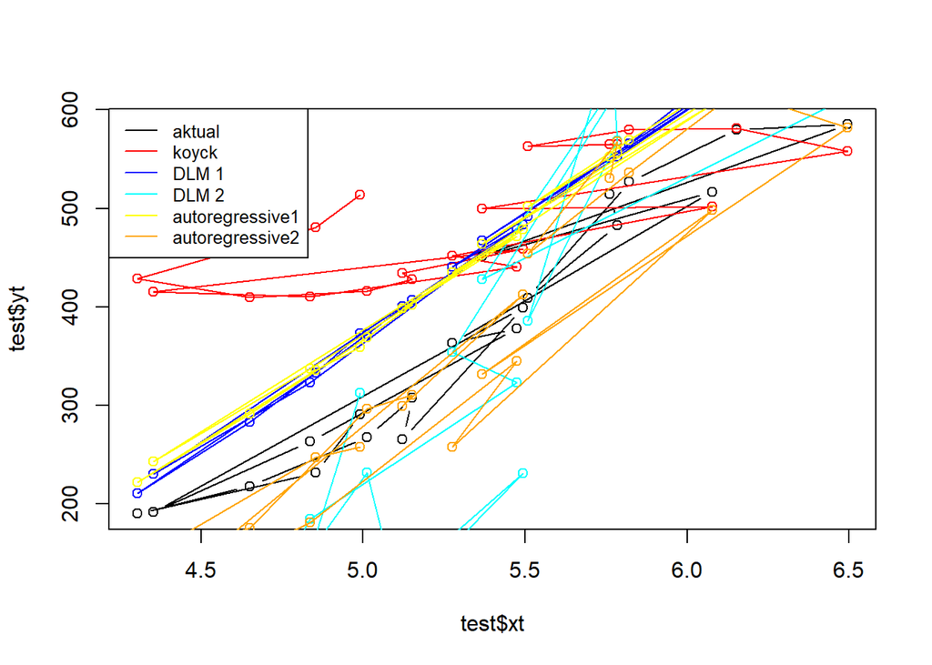

```r
par(mfrow=c(1,1))
plot(test$xt, test$yt, type="b", col="black")
points(test$xt, fore.koyck$forecasts,col="red")
lines(test$xt, fore.koyck$forecasts,col="red")
points(test$xt, fore.dlm$forecasts,col="blue")
lines(test$xt, fore.dlm$forecasts,col="blue")
points(test$xt, fore.dlm2$forecasts,col="cyan")
lines(test$xt, fore.dlm2$forecasts,col="cyan")
points(test$xt, fore.ardl$forecasts,col="yellow")
lines(test$xt, fore.ardl$forecasts,col="yellow")
points(test$xt, fore.ardl2$forecasts,col="orange")
lines(test$xt, fore.ardl2$forecasts,col="orange")
legend("topleft",c("aktual", "koyck","DLM 1","DLM 2", "autoregressive1", "autoregressive2"), lty=1, col=c("black","red","blue","cyan","yellow","orange"), cex=0.8)
```

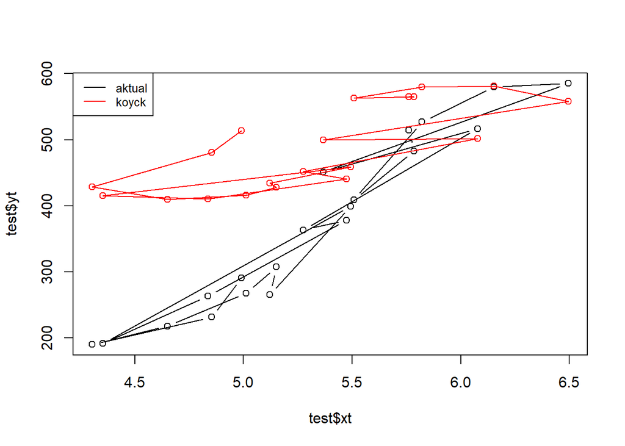

```r
par(mfrow=c(1,1))
plot(test$xt, test$yt, type="b", col="black")
points(test$xt, fore.koyck$forecasts,col="red")
lines(test$xt, fore.koyck$forecasts,col="red")
legend("topleft",c("aktual", "koyck"), lty=1, col=c("black","red"), cex=0.8)
```

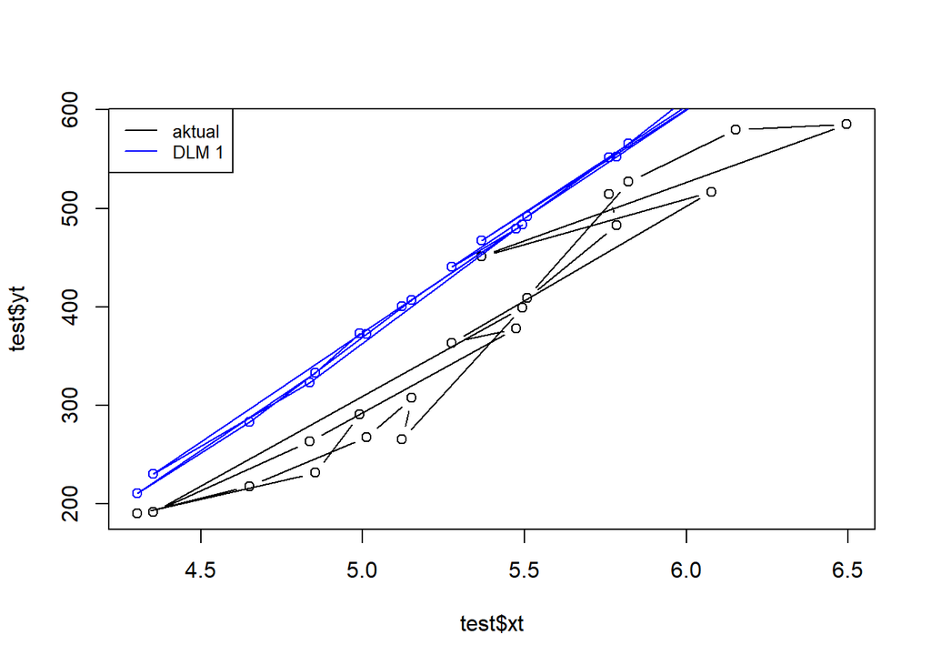

```r
par(mfrow=c(1,1))
plot(test$xt, test$yt, type="b", col="black")
points(test$xt, fore.dlm$forecasts,col="blue")
lines(test$xt, fore.dlm$forecasts,col="blue")
legend("topleft",c("aktual", "DLM 1"), lty=1, col=c("black","blue"), cex=0.8)
```

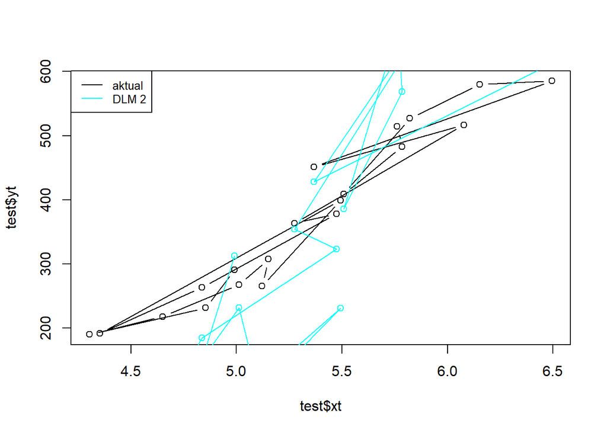

```r
par(mfrow=c(1,1))
plot(test$xt, test$yt, type="b", col="black")
points(test$xt, fore.dlm2$forecasts,col="cyan")
lines(test$xt, fore.dlm2$forecasts,col="cyan")
legend("topleft",c("aktual","DLM 2"), lty=1, col=c("black","cyan"), cex=0.8)
```

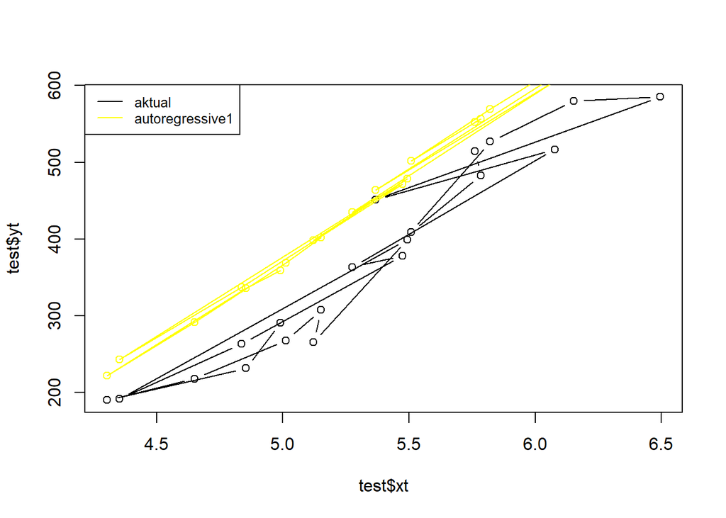

```r
par(mfrow=c(1,1))
plot(test$xt, test$yt, type="b", col="black")
points(test$xt, fore.ardl$forecasts,col="yellow")
lines(test$xt, fore.ardl$forecasts,col="yellow")
legend("topleft",c("aktual", "autoregressive1"), lty=1, col=c("black","yellow"), cex=0.8)
```

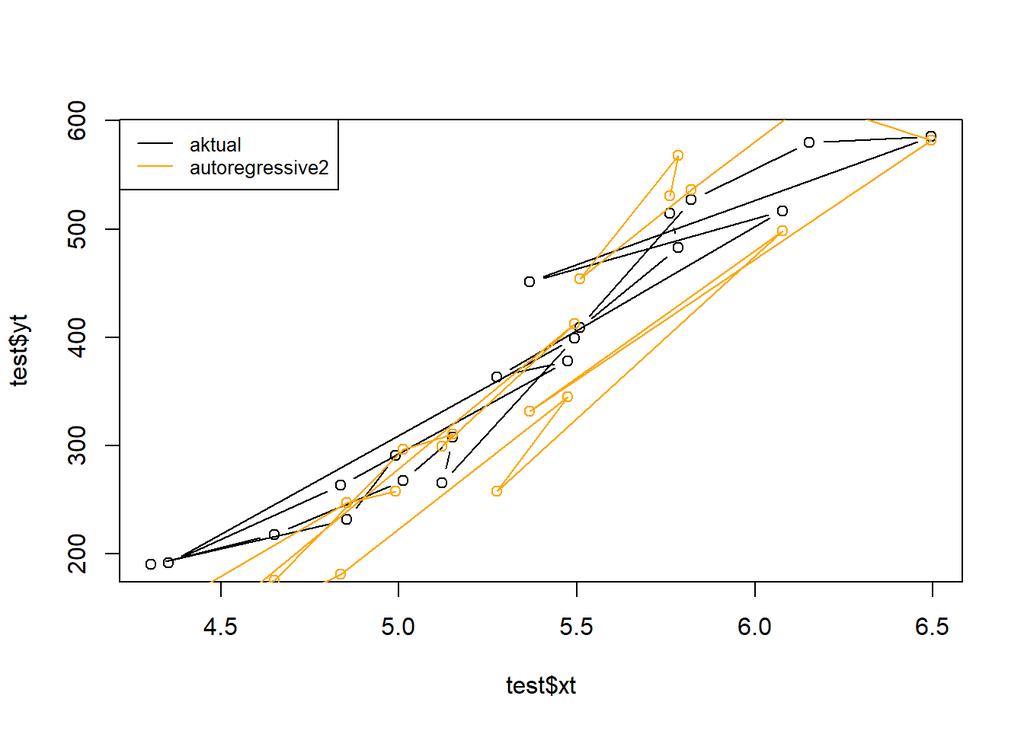

```r
par(mfrow=c(1,1))
plot(test$xt, test$yt, type="b", col="black")
points(test$xt, fore.ardl2$forecasts,col="orange")
lines(test$xt, fore.ardl2$forecasts,col="orange")
legend("topleft",c("aktual", "autoregressive2"), lty=1, col=c("black","orange"), cex=0.8)
```

Berdasarkan plot tersebut, terlihat bahwa plot yang paling mendekati data aktualnya adalah Model Autoregressive 2 (lag optimum), sehingga dapat disimpulkan model terbaik dalam hal ini adalah Model Autoregressive Distributed Lag